# Comparison of Data Imputation Methods Performance for Multiple System Estimation

### Nikolas Anova (2505401)

# Load libraries

```r
devtools::install_github("MaartenCruyff/mse")
library(mse)
library(mice)
library(ggmice)
library(dplyr)
library(VIM)
library(naniar)
library(ggplot2)
```

# Load Datasets

```r
load("comensha.Rdata")
head(comensha)
```

|  | I | K | O | P | R | Z | S | L | N | U | J | Freq |
| --- | --- | --- | --- | --- | --- | --- | --- | --- | --- | --- | --- | --- |
| 1 | 0 | 1 | 0 | 0 | 0 | 0 | F | A | NL | O | 2016 | 1 |
| 2 | 0 | 0 | 0 | 1 | 0 | 0 | F | A | NL | O | 2016 | 8 |
| 3 | 0 | 0 | 0 | 0 | 1 | 0 | F | A | NL | O | 2016 | 11 |
| 4 | 0 | 0 | 0 | 0 | 0 | 1 | F | A | NL | O | 2016 | 3 |
| 5 | 1 | 0 | 0 | 0 | 0 | 0 | M | A | NL | O | 2016 | 1 |
| 6 | 0 | 0 | 0 | 0 | 1 | 0 | M | A | NL | O | 2016 | 1 |

```r
tail(comensha)
```

|  | I | K | O | P | R | Z | S | L | N | U | J | Freq |
| --- | --- | --- | --- | --- | --- | --- | --- | --- | --- | --- | --- | --- |
| 426 | 0 | 0 | 0 | 1 | 0 | 0 | F | M | NA | S | 2019 | 1 |
| 427 | 0 | 0 | 0 | 0 | 1 | 0 | NA | M | NA | S | 2019 | 1 |
| 428 | 0 | 0 | 0 | 0 | 0 | 1 | NA | NA | NA | S | 2019 | 10 |
| 429 | NA | NA | 1 | NA | 1 | NA | F | M | O | NA | 2019 | 7 |
| 430 | 0 | 0 | 1 | 0 | 0 | 0 | NA | M | O | NA | 2019 | 3 |
| 431 | 0 | 0 | 0 | 0 | 1 | 0 | F | NA | NA | NA | 2019 | 7 |

# Missing Data Description

```r
# data missing pattern
summary(is.na(comensha))
```

```
     I               K               O               P               R               Z
 Mode :logical   Mode :logical   Mode :logical   Mode :logical   Mode :logical   Mode :logical
 FALSE:428       FALSE:428       FALSE:431       FALSE:428       FALSE:429       FALSE:430
 TRUE :3         TRUE :3                         TRUE :3         TRUE :2         TRUE :1
     S               L               N               U               J              Freq
 Mode :logical   Mode :logical   Mode :logical   Mode :logical   Mode :logical   Mode :logical
 FALSE:414       FALSE:406       FALSE:383       FALSE:426       FALSE:431       FALSE:431
 TRUE :17        TRUE :25        TRUE :48        TRUE :5
```

```
 Variables sorted by number of missings:
```

| Variable | Count |
| --- | --- |
| N | 0.111368910 |
| L | 0.058004640 |
| S | 0.039443155 |
| U | 0.011600928 |
| I | 0.006960557 |
| K | 0.006960557 |
| P | 0.006960557 |
| R | 0.004640371 |
| Z | 0.002320186 |
| O | 0.000000000 |

[output cut: 2 more lines]

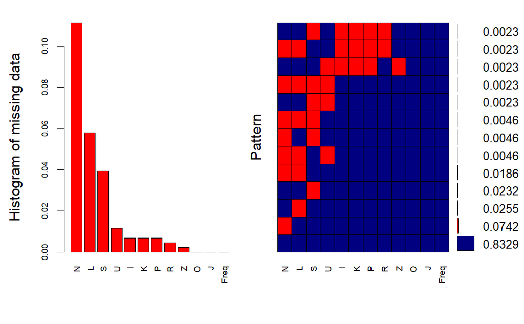

```r
aggr_plot <- aggr(comensha, col=c('navyblue','red'), numbers=TRUE, sortVars=TRUE, labels=names(comensha), cex.axis=.7, gap=3, ylab=c("Histogram of missing data","Pattern"))
```

# Check Missing Data Mechanism

```r
# Check if missing value in dataset is mcar or not.
mcartest <- mcar_test(comensha)
mcartest # low p-value, conclusion: is not mcar
```

| statistic | df | p.value | missing.patterns |
| --- | --- | --- | --- |
| 210.0555 | 109 | 2.147182e-08 | 13 |

# Data Imputations (Multiple Imputations)

Because it will be compared, all imputation methods used the same parameters, such as iteration number (maxit = 10), random seed value (seed = 1), and number of multiple imputations (m = 25).

### Predictive mean matching (pmm) imputation

```r
# Imputation
temp_pmm1 <- mice(comensha,m=25,maxit=10,meth='pmm',seed=1)
comensha_imp_pmm <- complete(temp_pmm1,1)
```

```r
summary(is.na(comensha_imp_pmm))
```

```
     I               K               O               P               R
 Mode :logical   Mode :logical   Mode :logical   Mode :logical   Mode :logical
 FALSE:431       FALSE:431       FALSE:431       FALSE:431       FALSE:431
     Z               S               L               N               U
 Mode :logical   Mode :logical   Mode :logical   Mode :logical   Mode :logical
 FALSE:431       FALSE:431       FALSE:431       FALSE:431       FALSE:431
     J              Freq
 Mode :logical   Mode :logical
 FALSE:431       FALSE:431
```

### Classification and regression trees (cart)

```r
# Imputation
temp_cart1 <- mice(comensha,m=25,maxit=10,meth='cart',seed=1)
comensha_imp_cart <- complete(temp_cart1,1)
```

```r
summary(is.na(comensha_imp_cart))
```

```
     I               K               O               P               R
 Mode :logical   Mode :logical   Mode :logical   Mode :logical   Mode :logical
 FALSE:431       FALSE:431       FALSE:431       FALSE:431       FALSE:431
     Z               S               L               N               U
 Mode :logical   Mode :logical   Mode :logical   Mode :logical   Mode :logical
 FALSE:431       FALSE:431       FALSE:431       FALSE:431       FALSE:431
     J              Freq
 Mode :logical   Mode :logical
 FALSE:431       FALSE:431
```

### Random Forest (rf) imputation

```r
# Imputation
temp_rf1 <- mice(comensha,m=25,maxit=10,meth='rf',seed=1)
comensha_imp_rf <- complete(temp_rf1,1)
```

```r
summary(is.na(comensha_imp_rf))
```

```
     I               K               O               P               R
 Mode :logical   Mode :logical   Mode :logical   Mode :logical   Mode :logical
 FALSE:431       FALSE:431       FALSE:431       FALSE:431       FALSE:431
     Z               S               L               N               U
 Mode :logical   Mode :logical   Mode :logical   Mode :logical   Mode :logical
 FALSE:431       FALSE:431       FALSE:431       FALSE:431       FALSE:431
     J              Freq
 Mode :logical   Mode :logical
 FALSE:431       FALSE:431
```

### Logistic regression (logreg) imputation

```r
# Imputation
temp_logreg1 <- mice(comensha,m=25,maxit=10,meth='logreg',seed=1)
comensha_imp_logreg <- complete(temp_logreg1,1)
```

```r
summary(is.na(comensha_imp_logreg))
```

```
     I               K               O               P               R
 Mode :logical   Mode :logical   Mode :logical   Mode :logical   Mode :logical
 FALSE:431       FALSE:431       FALSE:431       FALSE:431       FALSE:431
     Z               S               L               N               U
 Mode :logical   Mode :logical   Mode :logical   Mode :logical   Mode :logical
 FALSE:431       FALSE:431       FALSE:431       FALSE:431       FALSE:431
     J              Freq
 Mode :logical   Mode :logical
 FALSE:431       FALSE:431
```

### Logistic regression with bootstrap (logreg.boot)

```r
# Imputation
temp_logregboot1 <- mice(comensha,m=25,maxit=10,meth='logreg.boot',seed=1)
comensha_imp_logregboot <- complete(temp_logregboot1,1)
```

```r
summary(is.na(comensha_imp_logregboot))
```

```
     I               K               O               P               R
 Mode :logical   Mode :logical   Mode :logical   Mode :logical   Mode :logical
 FALSE:431       FALSE:431       FALSE:431       FALSE:431       FALSE:431
     Z               S               L               N               U
 Mode :logical   Mode :logical   Mode :logical   Mode :logical   Mode :logical
 FALSE:431       FALSE:431       FALSE:431       FALSE:431       FALSE:431
     J              Freq
 Mode :logical   Mode :logical
 FALSE:431       FALSE:431
```

### Lasso logistic regression (lasso.logreg)

```r
# Imputation
temp_lassologreg1 <- mice(comensha,m=25,maxit=10,meth='lasso.logreg',seed=1)
comensha_imp_lassologreg <- complete(temp_lassologreg1,1)
```

```r
summary(is.na(comensha_imp_lassologreg))
```

```
     I               K               O               P               R
 Mode :logical   Mode :logical   Mode :logical   Mode :logical   Mode :logical
 FALSE:431       FALSE:431       FALSE:431       FALSE:431       FALSE:431
     Z               S               L               N               U
 Mode :logical   Mode :logical   Mode :logical   Mode :logical   Mode :logical
 FALSE:431       FALSE:431       FALSE:431       FALSE:431       FALSE:431
     J              Freq
 Mode :logical   Mode :logical
 FALSE:431       FALSE:431
```

### Linear discriminant analysis (lda)

```r
# Imputation
temp_lda1 <- mice(comensha,m=25,maxit=10,meth='lda',seed=1)
comensha_imp_lda <- complete(temp_lda1,1)
```

```r
summary(is.na(comensha_imp_lda))
```

```
     I               K               O               P               R
 Mode :logical   Mode :logical   Mode :logical   Mode :logical   Mode :logical
 FALSE:431       FALSE:431       FALSE:431       FALSE:431       FALSE:431
     Z               S               L               N               U
 Mode :logical   Mode :logical   Mode :logical   Mode :logical   Mode :logical
 FALSE:431       FALSE:431       FALSE:431       FALSE:431       FALSE:431
     J              Freq
 Mode :logical   Mode :logical
 FALSE:431       FALSE:431
```

# Multiple System Estimation (MSE) Implementation (Model Selection)

Before do MSE model selection, convert imputed dataset into a dataset whose rows consist of all possible combinations of registers and covariates variables (Contingency Table).

```r
# model for 'xtabs' input
model <- Freq ~ I + K + O + P + R + Z + S + L + N + U + J

# Convert imputed dataset to Contingency Table
dpop_comensha_pmm <- as.data.frame(xtabs(model,comensha_imp_pmm))
dpop_comensha_cart <- as.data.frame(xtabs(model,comensha_imp_cart))
dpop_comensha_rf <- as.data.frame(xtabs(model,comensha_imp_rf))
dpop_comensha_logreg <- as.data.frame(xtabs(model,comensha_imp_logreg))
dpop_comensha_logregboot <- as.data.frame(xtabs(model,comensha_imp_logregboot))
dpop_comensha_lassologreg <- as.data.frame(xtabs(model,comensha_imp_lassologreg))
dpop_comensha_lda <- as.data.frame(xtabs(model,comensha_imp_lda))
```

Then do mse implementation: Model Selection with forward selection method.

### Imputed Dataset: Predictive mean matching (pmm)

```r
#Dataset from Predictive mean matching (pmm) imputation
mse_pmm1 <- model_search(x = dpop_comensha_pmm, lists=1:6, year = "J")
```

```r
mse_pmm1$models # List models with scale score.
```

|  | Step | Df | Deviance | Resid..Df | Resid..Dev | AIC | AICc | BIC | Nhat |
| --- | --- | --- | --- | --- | --- | --- | --- | --- | --- |
| 1 |  | NA | NA | 4018 | 9705.9 | 7199.2 | 7196.8 | 6806.3 | 13829.5 |
| 2 | + O:U | -1 | 1070.0 | 4017 | 8635.9 | 6131.2 | 6128.8 | 5744.7 | 13829.5 |
| 3 | + S:U | -1 | 1004.5 | 4016 | 7631.3 | 5128.6 | 5126.3 | 4748.7 | 13829.5 |
| 4 | + R:N | -1 | 897.4 | 4015 | 6733.9 | 4233.2 | 4230.9 | 3859.7 | 13829.5 |
| 5 | + S:N | -1 | 763.3 | 4014 | 5970.7 | 3472.0 | 3469.6 | 3104.9 | 13617.4 |
| 6 | + I:U | -1 | 476.9 | 4013 | 5493.7 | 2997.0 | 2994.7 | 2636.5 | 13944.2 |
| 7 | + P:J | -3 | 250.4 | 4010 | 5243.3 | 2752.7 | 2750.4 | 2411.5 | 13944.2 |
| 8 | + S:J | -3 | 246.5 | 4007 | 4996.9 | 2512.2 | 2510.0 | 2190.4 | 14017.7 |
| 9 | + Z:L | -1 | 221.3 | 4006 | 4775.5 | 2292.8 | 2290.6 | 1977.5 | 14017.7 |
| 10 | + L:N | -1 | 216.8 | 4005 | 4558.7 | 2078.1 | 2075.9 | 1769.2 | 14095.5 |

[output cut: 38 more lines]

```r
mse_pmm1$minima["AIC"] # unscale score from best AIC model.
```

```
 AIC
3738
```

```r
mse_pmm1$minima["BIC"] # unscale score from best BIC model.
```

```
   BIC
4221.4
```

### Imputed Dataset: Classification and regression trees (cart)

```r
#Dataset from Classification and regression trees (cart)
mse_cart1 <- model_search(x = dpop_comensha_cart, lists=1:6, year = "J")
```

```r
mse_cart1$models # List Models with scale score.
```

|  | Step | Df | Deviance | Resid..Df | Resid..Dev | AIC | AICc | BIC | Nhat |
| --- | --- | --- | --- | --- | --- | --- | --- | --- | --- |
| 1 |  | NA | NA | 4018 | 8711.4 | 6328.4 | 6325.4 | 5935.9 | 13829.5 |
| 2 | + O:U | -1 | 1070.0 | 4017 | 7641.4 | 5260.4 | 5257.4 | 4874.3 | 13829.5 |
| 3 | + S:U | -1 | 1013.6 | 4016 | 6627.7 | 4248.7 | 4245.7 | 3869.2 | 13829.5 |
| 4 | + S:N | -1 | 499.8 | 4015 | 6127.9 | 3750.9 | 3747.9 | 3377.8 | 13829.5 |
| 5 | + I:U | -1 | 495.8 | 4014 | 5632.1 | 3257.1 | 3254.1 | 2890.4 | 14244.3 |
| 6 | + L:N | -1 | 355.8 | 4013 | 5276.3 | 2903.3 | 2900.4 | 2543.1 | 14244.3 |
| 7 | + R:N | -1 | 291.0 | 4012 | 4985.3 | 2614.3 | 2611.4 | 2260.6 | 14095.0 |
| 8 | + P:J | -3 | 250.4 | 4009 | 4734.9 | 2369.9 | 2367.0 | 2035.6 | 14095.0 |
| 9 | + S:J | -3 | 245.6 | 4006 | 4489.3 | 2130.3 | 2127.5 | 1815.4 | 14219.2 |
| 10 | + P:R | -1 | 218.8 | 4005 | 4270.5 | 1913.5 | 1910.7 | 1605.0 | 20759.7 |

[output cut: 47 more lines]

```r
mse_cart1$minima["AIC"] #unscale score from best AIC model.
```

```
   AIC
3609.9
```

```r
mse_cart1$minima["BIC"] #unscale score from best BIC model.
```

```
   BIC
4092.9
```

### Imputed Dataset: Random Forest (rf)

```r
#Dataset from Random Forest (rf) imputation
mse_rf1 <- model_search(x = dpop_comensha_rf, lists=1:6, year = "J")
```

```r
mse_rf1$models # List Models with scale score.
```

|  | Step | Df | Deviance | Resid..Df | Resid..Dev | AIC | AICc | BIC | Nhat |
| --- | --- | --- | --- | --- | --- | --- | --- | --- | --- |
| 1 |  | NA | NA | 4018 | 8733.2 | 5967.6 | 5964.9 | 5575.1 | 13829.5 |
| 2 | + P:U | -1 | 809.9 | 4017 | 7923.3 | 5159.7 | 5157.0 | 4773.7 | 13829.5 |
| 3 | + S:U | -1 | 581.9 | 4016 | 7341.4 | 4579.8 | 4577.1 | 4200.3 | 13829.5 |
| 4 | + R:S | -1 | 547.4 | 4015 | 6794.0 | 4034.4 | 4031.7 | 3661.3 | 14665.0 |
| 5 | + S:N | -1 | 470.5 | 4014 | 6323.5 | 3565.9 | 3563.2 | 3199.3 | 14665.0 |
| 6 | + K:U | -1 | 411.2 | 4013 | 5912.2 | 3156.7 | 3154.0 | 2796.5 | 16232.8 |
| 7 | + L:N | -1 | 322.2 | 4012 | 5590.0 | 2836.5 | 2833.8 | 2482.8 | 16232.8 |
| 8 | + K:P | -1 | 266.0 | 4011 | 5324.0 | 2572.5 | 2569.9 | 2225.2 | 14221.4 |
| 9 | + S:J | -3 | 254.8 | 4008 | 5069.3 | 2323.7 | 2321.2 | 1995.9 | 14221.4 |
| 10 | + P:J | -3 | 277.3 | 4005 | 4791.9 | 2052.4 | 2049.9 | 1743.9 | 14016.3 |

[output cut: 44 more lines]

```r
mse_rf1$minima["AIC"] #unscale score from best AIC model.
```

```
   AIC
4006.8
```

```r
mse_rf1$minima["BIC"] #unscale score from best BIC model.
```

```
   BIC
4489.8
```

### Imputed Dataset: Logistic regression (logreg)

```r
#Dataset from Logistic regression (logreg) imputation
mse_logreg1 <- model_search(x = dpop_comensha_logreg, lists=1:6, year = "J")
```

```r
mse_logreg1$models #List Models with scale score.
```

|  | Step | Df | Deviance | Resid..Df | Resid..Dev | AIC | AICc | BIC | Nhat |
| --- | --- | --- | --- | --- | --- | --- | --- | --- | --- |
| 1 |  | NA | NA | 4018 | 8527.4 | 5923.2 | 5920.4 | 5540.0 | 13829.5 |
| 2 | + P:U | -1 | 809.9 | 4017 | 7717.5 | 5115.4 | 5112.6 | 4738.6 | 13829.5 |
| 3 | + O:U | -1 | 413.6 | 4016 | 7303.9 | 4703.8 | 4701.0 | 4333.5 | 12871.7 |
| 4 | + L:N | -1 | 383.1 | 4015 | 6920.8 | 4322.7 | 4319.9 | 3958.9 | 12871.7 |
| 5 | + S:N | -1 | 382.9 | 4014 | 6537.9 | 3941.8 | 3939.0 | 3584.4 | 12871.7 |
| 6 | + S:U | -1 | 330.5 | 4013 | 6207.5 | 3613.3 | 3610.6 | 3262.4 | 12871.7 |
| 7 | + S:J | -3 | 319.9 | 4010 | 5887.6 | 3299.4 | 3296.7 | 2967.9 | 12871.7 |
| 8 | + P:J | -3 | 325.4 | 4007 | 5562.2 | 2980.0 | 2977.4 | 2667.9 | 12871.7 |
| 9 | + I:U | -1 | 294.0 | 4006 | 5268.2 | 2688.1 | 2685.5 | 2382.4 | 12805.2 |
| 10 | + R:N | -1 | 220.4 | 4005 | 5047.8 | 2469.6 | 2467.0 | 2170.5 | 12754.3 |

[output cut: 44 more lines]

```r
mse_logreg1$minima["AIC"] # unscale score from best AIC model.
```

```
   AIC
3835.1
```

```r
mse_logreg1$minima["BIC"] # unscale score from best BIC model.
```

```
   BIC
4308.8
```

### Imputed Dataset: Logistic regression with bootstrap (logreg.boot)

```r
#Dataset from Logistic regression with bootstrap (logreg.boot) imputation
mse_logregboot1 <- model_search(x = dpop_comensha_logregboot, lists=1:6, year = "J")
```

```r
mse_logregboot1$models #List Models with scale score.
```

|  | Step | Df | Deviance | Resid..Df | Resid..Dev | AIC | AICc | BIC | Nhat |
| --- | --- | --- | --- | --- | --- | --- | --- | --- | --- |
| 1 |  | NA | NA | 4018 | 8741.4 | 6291.2 | 6288.3 | 5908.6 | 13829.5 |
| 2 | + O:U | -1 | 1077.6 | 4017 | 7663.8 | 5215.5 | 5212.6 | 4839.4 | 13829.5 |
| 3 | + S:U | -1 | 964.0 | 4016 | 6699.8 | 4253.6 | 4250.7 | 3883.9 | 13829.5 |
| 4 | + S:N | -1 | 518.5 | 4015 | 6181.3 | 3737.0 | 3734.2 | 3373.8 | 13829.5 |
| 5 | + I:U | -1 | 498.4 | 4014 | 5682.8 | 3240.6 | 3237.7 | 2883.9 | 14248.5 |
| 6 | + L:N | -1 | 328.2 | 4013 | 5354.7 | 2914.4 | 2911.6 | 2564.1 | 14248.5 |
| 7 | + R:N | -1 | 285.1 | 4012 | 5069.6 | 2631.3 | 2628.5 | 2287.5 | 14100.9 |
| 8 | + P:J | -3 | 250.4 | 4009 | 4819.2 | 2387.0 | 2384.2 | 2062.5 | 14100.9 |
| 9 | + S:J | -3 | 275.5 | 4006 | 4543.7 | 2117.5 | 2114.8 | 1812.4 | 14230.9 |
| 10 | + P:R | -1 | 219.9 | 4005 | 4323.8 | 1899.6 | 1896.9 | 1601.0 | 20799.6 |

[output cut: 46 more lines]

```r
mse_logregboot1$minima["AIC"] # unscale score from best AIC model.
```

```
   AIC
3685.1
```

```r
mse_logregboot1$minima["BIC"] # unscale score from best BIC model.
```

```
   BIC
4158.2
```

### Imputed Dataset: Lasso logistic regression (lasso.logreg)

```r
#Dataset from Lasso logistic regression (lasso.logreg) imputation
mse_lassologreg1 <- model_search(x = dpop_comensha_lassologreg, lists=1:6, year = "J")
```

```r
mse_lassologreg1$models #List Models with scale score.
```

|  | Step | Df | Deviance | Resid..Df | Resid..Dev | AIC | AICc | BIC | Nhat |
| --- | --- | --- | --- | --- | --- | --- | --- | --- | --- |
| 1 |  | NA | NA | 4018 | 8759.0 | 6228.6 | 6225.7 | 5835.5 | 13829.5 |
| 2 | + O:U | -1 | 1047.9 | 4017 | 7711.0 | 5182.6 | 5179.7 | 4796.0 | 13829.5 |
| 3 | + S:U | -1 | 1046.8 | 4016 | 6664.2 | 4137.9 | 4135.0 | 3757.7 | 13829.5 |
| 4 | + I:U | -1 | 499.2 | 4015 | 6165.0 | 3640.6 | 3637.8 | 3266.9 | 14244.0 |
| 5 | + S:N | -1 | 470.0 | 4014 | 5695.0 | 3172.6 | 3169.7 | 2805.3 | 14244.0 |
| 6 | + L:N | -1 | 331.6 | 4013 | 5363.4 | 2843.0 | 2840.2 | 2482.2 | 14244.0 |
| 7 | + P:J | -3 | 250.4 | 4010 | 5113.0 | 2598.6 | 2595.9 | 2257.3 | 14244.0 |
| 8 | + S:J | -3 | 251.6 | 4007 | 4861.5 | 2353.1 | 2350.4 | 2031.1 | 14420.5 |
| 9 | + P:R | -1 | 221.3 | 4006 | 4640.1 | 2133.7 | 2131.0 | 1818.2 | 21151.0 |
| 10 | + O:Z | -1 | 195.5 | 4005 | 4444.6 | 1940.2 | 1937.5 | 1631.1 | 25796.8 |

[output cut: 48 more lines]

```r
mse_lassologreg1$minima["AIC"] # unscale score from best AIC model.
```

```
   AIC
3765.3
```

```r
mse_lassologreg1$minima["BIC"] # unscale score from best BIC model.
```

```
   BIC
4248.9
```

### Imputed Dataset: Linear discriminant analysis (lda)

```r
#Dataset from Linear discriminant analysis (lda)
mse_lda1 <- model_search(x = dpop_comensha_lda, lists=1:6, year = "J")
```

```r
mse_lda1$models #List Models with scale score.
```

|  | Step | Df | Deviance | Resid..Df | Resid..Dev | AIC | AICc | BIC | Nhat |
| --- | --- | --- | --- | --- | --- | --- | --- | --- | --- |
| 1 |  | NA | NA | 4018 | 8641.6 | 6198.6 | 6196.0 | 5814.1 | 13560.9 |
| 2 | + S:U | -1 | 1068.0 | 4017 | 7573.6 | 5132.6 | 5130.0 | 4754.5 | 13560.9 |
| 3 | + O:U | -1 | 999.5 | 4016 | 6574.2 | 4135.1 | 4132.5 | 3763.5 | 13560.9 |
| 4 | + I:U | -1 | 481.3 | 4015 | 6092.9 | 3655.8 | 3653.2 | 3290.7 | 13935.2 |
| 5 | + S:N | -1 | 465.7 | 4014 | 5627.2 | 3192.1 | 3189.6 | 2833.5 | 13935.2 |
| 6 | + L:N | -1 | 334.2 | 4013 | 5293.0 | 2859.9 | 2857.4 | 2507.7 | 13935.2 |
| 7 | + P:J | -3 | 237.7 | 4010 | 5055.3 | 2628.2 | 2625.7 | 2295.4 | 13935.2 |
| 8 | + S:J | -3 | 262.6 | 4007 | 4792.7 | 2371.7 | 2369.2 | 2058.3 | 14088.7 |
| 9 | + P:R | -1 | 200.6 | 4006 | 4592.1 | 2173.0 | 2170.6 | 1866.1 | 20066.8 |
| 10 | + O:Z | -1 | 187.1 | 4005 | 4405.0 | 1988.0 | 1985.6 | 1687.5 | 24108.6 |

[output cut: 43 more lines]

```r
mse_lda1$minima["AIC"] # unscale score from best AIC model.
```

```
   AIC
3680.5
```

```r
mse_lda1$minima["BIC"] # unscale score from best BIC model.
```

```
   BIC
4155.5
```

# Comparison MSE Models from 7 imputed datasets

### AIC Version

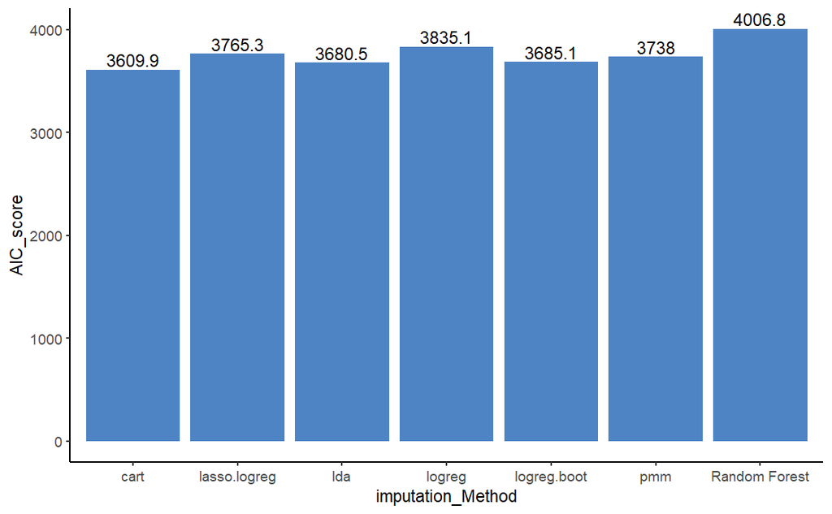

```r
# Visualization AIC
aic_recap <- data.frame(
  imputation_Method=c("pmm","cart","Random Forest","logreg","logreg.boot","lasso.logreg","lda"),
  AIC_score=c(mse_pmm1$minima["AIC"],mse_cart1$minima["AIC"],mse_rf1$minima["AIC"],
          mse_logreg1$minima["AIC"],mse_logregboot1$minima["AIC"],mse_lassologreg1$minima["AIC"],
          mse_lda1$minima["AIC"])
)

ggplot(aic_recap, aes(x=imputation_Method, y=AIC_score)) +
  geom_bar(stat = "identity", fill="#4E84C4") +
  geom_text(aes(label=AIC_score), position=position_dodge(width=0.9), vjust=-0.25) +
  theme(panel.grid.major = element_blank(), panel.grid.minor = element_blank(),
        panel.background = element_blank(), axis.line = element_line(colour = "black"))
```

Based on result above, Classification and regression trees (cart) imputed dataset give smallest AIC. So, best AIC model is from cart imputed dataset.

### BIC Version

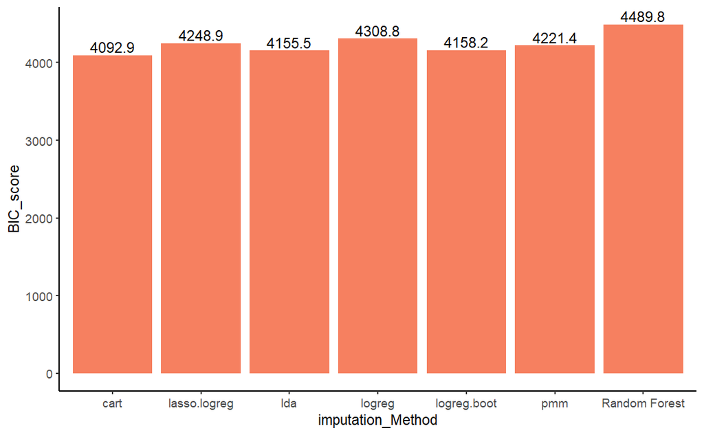

```r
bic_recap <- data.frame(
  imputation_Method=c("pmm","cart","Random Forest","logreg","logreg.boot","lasso.logreg","lda") ,
  BIC_score=c(mse_pmm1$minima["BIC"],mse_cart1$minima["BIC"],mse_rf1$minima["BIC"],
              mse_logreg1$minima["BIC"],mse_logregboot1$minima["BIC"],mse_lassologreg1$minima["BIC"],
              mse_lda1$minima["BIC"])
)

ggplot(bic_recap, aes(x=imputation_Method, y=BIC_score)) +
  geom_bar(stat = "identity",fill="#f68060") +
  geom_text(aes(label=BIC_score), position=position_dodge(width=0.9), vjust=-0.25) +
  theme(panel.grid.major = element_blank(), panel.grid.minor = element_blank(),
        panel.background = element_blank(), axis.line = element_line(colour = "black"))
```

Based on result above, Classification and regression trees (cart) imputed dataset give smallest BIC. So, best BIC model is from cart imputed dataset.

# Comparison 2 MSE Models from best AIC and BIC version

### Complexity Model

```r
# Best Model from AIC version
mse_cart1$formulas[54] # AIC
```

```
[[1]]
Freq ~ I + K + O + P + R + Z + S + L + N + U + J + O:U + S:U +
    S:N + I:U + L:N + R:N + P:J + S:J + P:R + O:Z + L:J + Z:L +
    K:N + K:S + O:N + R:S + L:U + R:J + P:U + K:P + N:J + Z:N +
    P:Z + I:L + K:L + K:J + U:J + I:Z + K:U + O:L + I:P + I:N +
    I:R + O:P + Z:U + R:U + S:L + P:S + K:O + O:J + I:J + K:R +
    I:O + Z:S + N:U + I:S + P:L + I:K + Z:J + K:Z + O:S
<environment: 0x0000021d26aacc28>
```

```r
# Best Model from BIC version
mse_cart1$formulas[42]# BIC
```

```
[[1]]
Freq ~ I + K + O + P + R + Z + S + L + N + U + J + O:U + S:U +
    S:N + I:U + L:N + R:N + P:J + S:J + P:R + O:Z + L:J + Z:L +
    K:N + K:S + O:N + R:S + L:U + R:J + P:U + K:P + N:J + Z:N +
    P:Z + I:L + K:L + K:J + U:J + I:Z + K:U + O:L + I:P + I:N +
    I:R + O:P + Z:U + R:U + S:L + P:S + K:O
<environment: 0x0000021d26aacc28>
```

the BIC model has fewer parameters than the AIC model. So the AIC model is more complex than the BIC. The aim is to find models that are neither too simple nor too complex, and thus trade-off between bias and variance. So the BIC version model (from cart imputation) is better.

### Standard Error of Population Estimation

```r
# Do Multiple System Estimation: Estimating Population by Year and Covariates
boot_mse_cart1_aic <- boot_mse(mse_cart1, modelnr = 54)
boot_mse_cart1_bic <- boot_mse(mse_cart1, modelnr = 42)
```

```r
# Calculate Normalized Standard Error from Confidence Interval 95%
# AIC version
aic_est <- as.data.frame(boot_mse_cart1_aic$tables$J)
aic_est$Norm_Std_Error <- round(((aic_est$max95-aic_est$min95)/3.92)/aic_est$Nhat,2)
aic_est
```

|  | Year | nobs | Nhat | min95 | max95 | Norm_Std_Error |
| --- | --- | --- | --- | --- | --- | --- |
| 2016 | 2016 | 1015 | 4512 | 3513 | 6258 | 0.16 |
| 2017 | 2017 | 1002 | 3208 | 2550 | 4181 | 0.13 |
| 2018 | 2018 | 1311 | 6023 | 4735 | 7884 | 0.13 |
| 2019 | 2019 | 1414 | 5812 | 4647 | 7814 | 0.14 |

```r
# BIC version
bic_est <- as.data.frame(boot_mse_cart1_bic$tables$J)
bic_est$Norm_Std_Error <- round(((bic_est$max95-bic_est$min95)/3.92)/bic_est$Nhat,2)
bic_est
```

|  | Year | nobs | Nhat | min95 | max95 | Norm_Std_Error |
| --- | --- | --- | --- | --- | --- | --- |
| 2016 | 2016 | 1015 | 6504 | 5279 | 8173 | 0.11 |
| 2017 | 2017 | 1002 | 5133 | 4213 | 6465 | 0.11 |
| 2018 | 2018 | 1311 | 7751 | 6409 | 9698 | 0.11 |
| 2019 | 2019 | 1414 | 6063 | 5039 | 7524 | 0.10 |

the AIC model produced population estimations that had higher normalized standard error than the BIC model. Therefore, based on the normalized standard error, the BIC model produces a better estimation of the human trafficking population than the AIC model.

### Reasonableness of Population Estimation

Reasonableness of Population Estimation can be seen from Ratio of Estimated (NHat) and Observed (nobs) population. If the estimated population does not explode in number compared to the observed population, it can be said that the estimated population is still reasonable.

```r
# Calculate ratio between estimated and observed victims (reasonableness population)
# AIC version
aic_est$ratio <- round(aic_est$Nhat/aic_est$nobs,1)
aic_est
```

|  | Year | nobs | Nhat | min95 | max95 | Norm_Std_Error | ratio |
| --- | --- | --- | --- | --- | --- | --- | --- |
| 2016 | 2016 | 1015 | 4512 | 3513 | 6258 | 0.16 | 4.4 |
| 2017 | 2017 | 1002 | 3208 | 2550 | 4181 | 0.13 | 3.2 |
| 2018 | 2018 | 1311 | 6023 | 4735 | 7884 | 0.13 | 4.6 |
| 2019 | 2019 | 1414 | 5812 | 4647 | 7814 | 0.14 | 4.1 |

```r
# BIC version
bic_est$ratio <- round(bic_est$Nhat/bic_est$nobs,1)
bic_est
```

|  | Year | nobs | Nhat | min95 | max95 | Norm_Std_Error | ratio |
| --- | --- | --- | --- | --- | --- | --- | --- |
| 2016 | 2016 | 1015 | 6504 | 5279 | 8173 | 0.11 | 6.4 |
| 2017 | 2017 | 1002 | 5133 | 4213 | 6465 | 0.11 | 5.1 |
| 2018 | 2018 | 1311 | 7751 | 6409 | 9698 | 0.11 | 5.9 |
| 2019 | 2019 | 1414 | 6063 | 5039 | 7524 | 0.10 | 4.3 |

The ratio values of the two models (AIC and BIC) between the estimated and observed populations are still reasonable and do not differ much. So the population estimates of both models are still reasonable.

### Recapitulation

Based on the comparison of the three criteria above, the BIC model is better than the AIC model. So, the BIC version model (from cart imputation) is chosen as the best model.

# Population Estimation Results from selected model (CART Imputation BIC Version)

### By Year

```r
boot_mse_cart1_bic$tables$J
```

```
     Year nobs Nhat min95 max95
2016 2016 1015 6504  5279  8173
2017 2017 1002 5133  4213  6465
2018 2018 1311 7751  6409  9698
2019 2019 1414 6063  5039  7524
```

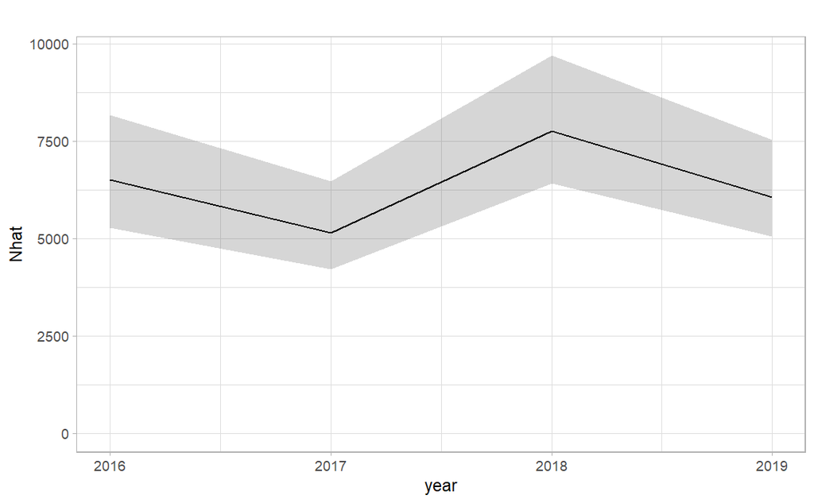

```r
boot_mse_cart1_bic$plots$J
```

### By Year and Age (Adult / Minor)

```r
boot_mse_cart1_bic$tables$L
```

```
  Year nobs Nhat min95 max95
A 2016  788 4995  4056  6336
A 2017  813 4118  3366  5214
A 2018 1248 7439  6116  9328
A 2019 1277 5517  4612  6833
M 2016  227 1509  1163  1984
M 2017  189 1015   793  1350
M 2018   63  312   218   428
M 2019  137  547   421   714
```

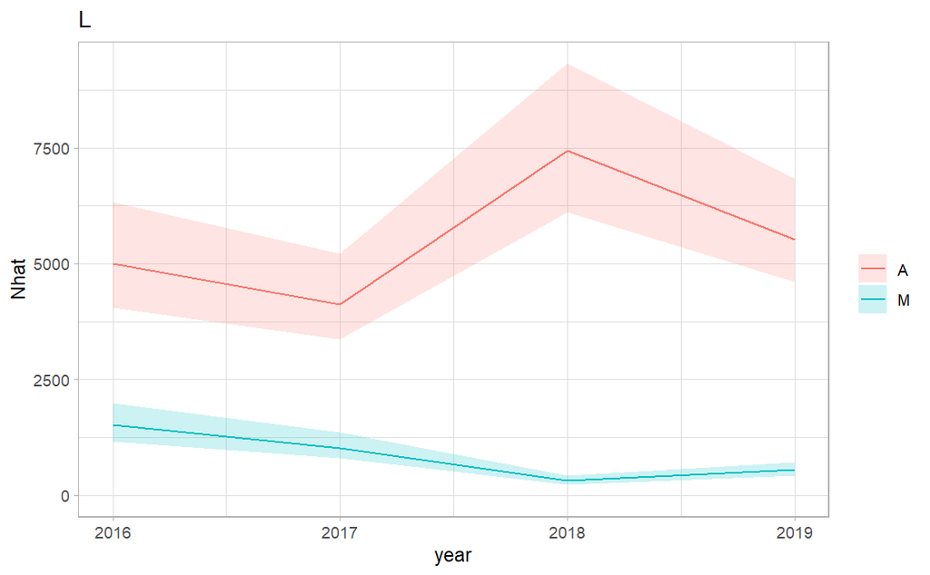

```r
boot_mse_cart1_bic$plots$L
```

### By Year and Sex (Male / Female)

```r
boot_mse_cart1_bic$tables$S
```

```
  Year nobs Nhat min95 max95
F 2016  806 4921  3960  6248
F 2017  768 3538  2873  4485
F 2018  866 4455  3610  5634
F 2019  768 2873  2350  3557
M 2016  209 1583  1229  2069
M 2017  234 1595  1256  2092
M 2018  445 3296  2609  4192
M 2019  646 3191  2588  4097
```

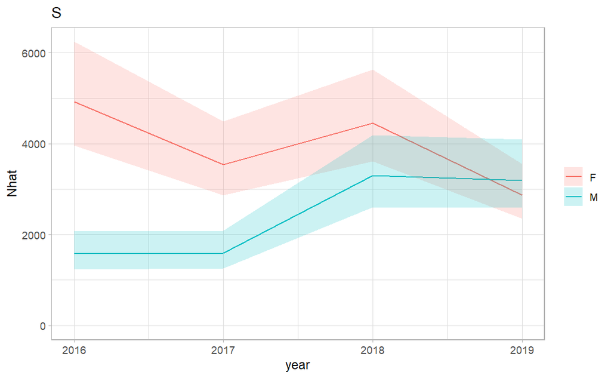

```r
boot_mse_cart1_bic$plots$S
```

### By Year and Nationality (NL / Non-NL)

```r
boot_mse_cart1_bic$tables$N
```

```
   Year nobs Nhat min95 max95
NL 2016  326 2498  1944  3270
NL 2017  333 1885  1487  2464
NL 2018  223 1198   922  1561
NL 2019  251 1057   844  1350
O  2016  689 4006  3288  5029
O  2017  669 3248  2643  4090
O  2018 1088 6553  5397  8194
O  2019 1163 5007  4168  6216
```

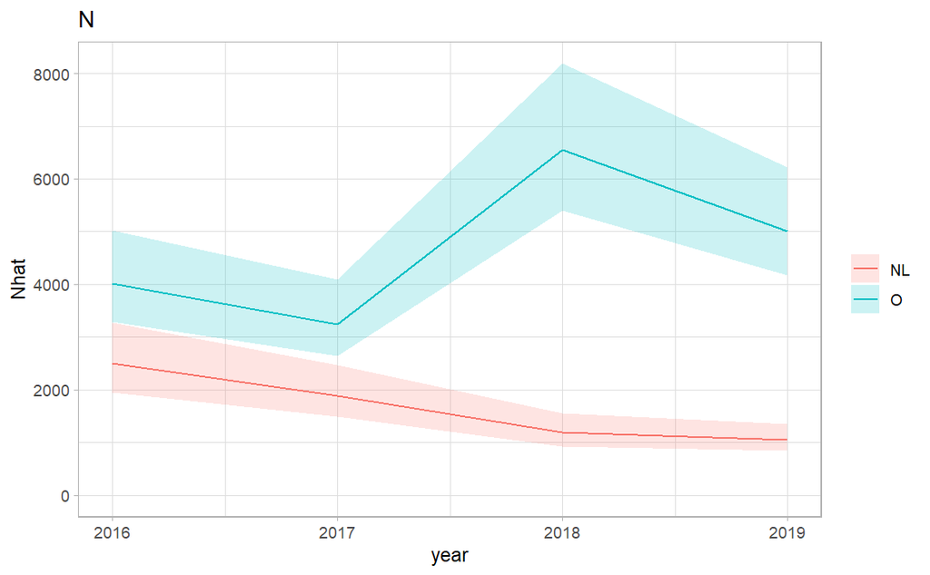

```r
boot_mse_cart1_bic$plots$N
```

### By Year and Type of Exploitation (Others / Sexual)

```r
boot_mse_cart1_bic$tables$U
```

```
  Year nobs Nhat min95 max95
O 2016  383 3320  2610  4300
O 2017  361 2683  2112  3543
O 2018  408 3227  2540  4235
O 2019  496 3088  2449  4084
S 2016  632 3184  2498  4143
S 2017  641 2450  1964  3129
S 2018  903 4523  3641  5732
S 2019  918 2976  2445  3669
```

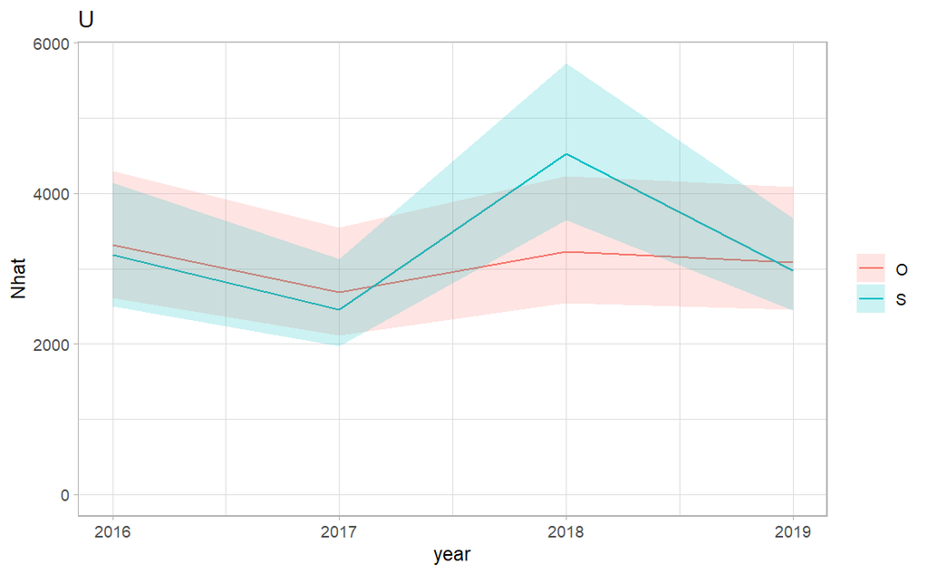

```r
boot_mse_cart1_bic$plots$U
```

# Conclusion

From the seven multiple imputation methods used to impute data on Human Trafficking Victims in the Netherlands 2016 - 2019, the classification and regression trees (CART) method produces the best Multiple System Estimation (MSE) model compared to other imputation methods.

Different imputation methods produce quite varied MSE model scores. This shows that, if there is a problem of missing data in the application of MSE, the choice of imputation method is proven to affect the quality of the output from MSE.

When compared by version, the BIC model from the CART method is better than its the AIC version. This can be seen from the complexity of the model, standard error and reasonableness of the population estimation. The BIC model is better on the criteria of model complexity and standard error. Meanwhile, both models have reasonableness in their population estimates.